# HW2: Mitochondrial Eve

2024-10-20

# Task

Get data from the resource, make a phylogenetic tree and answer some questions about how human have populated the world

# Script

## Setup

Attach libs

[output not shown]

Create env, download scripts and programms:

```bash
conda create --name hw1_phylo
conda activate hw1_phylo

conda install bioconda::mafft
conda install bioconda::iqtree
```

## MAFFT

Make alignment files:

- across human `human.fa`
- across different *Homo* species `homo.fa`
- with added outgroup for *Homo* `full.fa`

```bash
cat Human/* >> raw.fa
mafft raw.fa > human.fa

cat Neanderthal/* >> raw.fa
cat Denisova/* >> raw.fa
mafft raw.fa > homo.fa

cat Pan/* >> raw.fa
mafft raw.fa > full.fa
```

## Phylogeny

I select `iqtree` for tree reconstruction - for simplicity

### Human

```bash
mkdir -p iqtree/human

iqtree -s human.fa \
  -m MFP -B 1000 -safe

mv human.fa.* iqtree/human/
```

### Homo

Get outgroups:

```bash
grep ">" Denisova/* >> out1
grep ">" Neanderthal/* >> out1

out1=$(cat out1 | sed 's/.*:>//g' | sed 's/ .*//g' | tr '\n' ',' | head -c -1)
```

Reconstruct:

```bash
mkdir -p iqtree/homo

iqtree -s homo.fa \
  -o $out1 \
  -m MFP -B 1000 -safe

mv homo.fa.* iqtree/homo/
```

### Full

Get outgroups:

```bash
grep ">" Pan/* >> out2

out2=$(cat out2 | sed 's/.*:>//g' | sed 's/ .*//g' | tr '\n' ',' | head -c -1)
```

Reconstruct:

```bash
mkdir -p iqtree/full

iqtree -s full.fa \
  -o $out2 \
  -m MFP -B 1000 -safe

mv full.fa.* iqtree/full
```

## Analysis

### IQ-TREE model finder

```bash
for dir in $(ls iqtree); do
  echo $dir
  gzip -d iqtree/$dir/*model.gz
  grep "best_model" iqtree/$dir/*model
  gzip iqtree/$dir/*model
  echo -e "#####\n"
done
```

```
## full
## best_model_AIC: GTR+F+R4
## best_model_AICc: GTR+F+R4
## best_model_BIC: TIM2+F+R3
## best_model_list_BIC: TIM2+F+R3 TN+F+R3 TPM2u+F+R3 HKY+F+R3 TIM2+F+I+R3 TIM3+F+R3 TIM+F+R3 TN+F+I+R3 TPM2u+F+I+R3 TPM3u+F+R3 K3Pu+F+R3 HKY+F+I+R3 GTR+F+R3 TIM3+F+I+R3 TIM+F+I+R3 TVM+F+R3 TPM3u+F+I+R3 K3Pu+F+I+R3 GTR+F+I+R3 GTR+F+R4 TVM+F+I+R3 GTR+F+I+R4 GTR+F+I+G4 GTR+F+I GTR+F+R2 GTR+F+I+R2 GTR+F…
## #####
##
## homo
## best_model_AIC: TIM2+F+R3
## best_model_AICc: TIM2+F+R3
## best_model_BIC: TN+F+R3
## best_model_list_BIC: TN+F+R3 TIM2+F+R3 TIM3+F+R3 TIM+F+R3 TN+F+I+R3 TIM2+F+I+R3 TIM3+F+I+R3 TIM+F+I+R3 GTR+F+R3 TPM2u+F+R3 HKY+F+R3 GTR+F+I+R3 TPM3u+F+R3 K3Pu+F+R3 TPM2u+F+I+R3 HKY+F+I+R3 GTR+F+R4 TVM+F+R3 TPM3u+F+I+R3 K3Pu+F+I+R3 GTR+F+I+R4 TVM+F+I+R3 GTR+F+I+G4 GTR+F+I GTR+F+R2 GTR+F+I+R2 GTR+F…
## #####
##
## human
## best_model_AIC: TIM2+F+R3
## best_model_AICc: TIM2+F+R3
## best_model_BIC: TN+F+R3
## best_model_list_BIC: TN+F+R3 TIM2+F+R3 TIM3+F+R3 TIM+F+R3 TN+F+I+R3 TIM2+F+I+R3 HKY+F+R3 TPM2u+F+R3 TIM3+F+I+R3 TIM+F+I+R3 GTR+F+R3 TPM3u+F+R3 K3Pu+F+R3 HKY+F+I+R3 TPM2u+F+I+R3 GTR+F+I+R3 TPM3u+F+I+R3 K3Pu+F+I+R3 TVM+F+R3 GTR+F+R4 TVM+F+I+R3 GTR+F+I+R4 GTR+F+I GTR+F+I+G4 GTR+F+R2 GTR+F+I+R2 GTR+F…
## #####
```

### Tree vizualizations

Read headers of files and compile the legend:

```bash
grep ">" full.fa > legend
```

```r
legend <- readLines("legend")
legend <- data.frame(

  label = legend %>%
    str_remove_all(">") %>%
    str_remove_all(" .*"),

  haplo = legend %>%
    str_extract("(?<=haplogroup )[^ ]*"),

  color = legend %>%
    str_extract("(?<=haplogroup )[^ ]"),

  sp = legend %>%
    str_extract(">[^ ]* [^ ]* [^ ]* [^ ]* [^ ]*") %>%
    str_remove_all(">[^ ]* ") %>%
    str_remove("Homo [^ ]* ") %>%
    str_remove(" isolate") %>%
    str_remove("ssp. ") %>%
    str_remove(" mitoch.*") %>%
    str_remove(" complete") %>%
    str_replace("Altai", "Denisova")
) %>%
  mutate(clear = ifelse(
    is.na(haplo),
    sp,
    haplo
  ))

legend %>% tibble
```

```
## # A tibble: 55 × 5
##    label      haplo    color sp                   clear
##    <chr>      <chr>    <chr> <chr>                <chr>
##  1 JQ247408.1 A2f1a    A     haplogroup A2f1a     A2f1a
##  2 KX459697.1 A4-A200G A     haplogroup A4-A200G  A4-A200G
##  3 KP172434.1 B2       B     isolate GranChaco16  B2
##  4 JF499899.1 B4d1     B     haplogroup B4d1      B4d1
##  5 KP017255.1 C1d3     C     isolate CH2D01_20    C1d3
##  6 JF811749.1 C4a1     C     haplogroup C4a1      C4a1
##  7 KP172432.1 D1       D     isolate GranChaco561 D1
##  8 JN084079.1 D4e1a1   D     haplogroup D4e1a1    D4e1a1
##  9 HQ259121.1 F1a3     F     haplogroup F1a3      F1a3
## 10 KU521454.1 F3b1     F     isolate PAI17        F3b1
## # ℹ 45 more rows
```

Read .contree:

```r
rt <- function(fname){
  nm <- paste0("iqtree/", fname, "/", fname, ".fa.contree")

  tmp <- read.tree(nm)
  legend_tmp <- legend %>%
    subset(label %in% tmp$tip.label)
  tmp <- ggtree(tmp)$data %>%
    full_join(legend, by= "label")

  return(tmp)
}

full <- rt("full")
homo <- rt("homo")
human <- rt("human")
```

Viz:

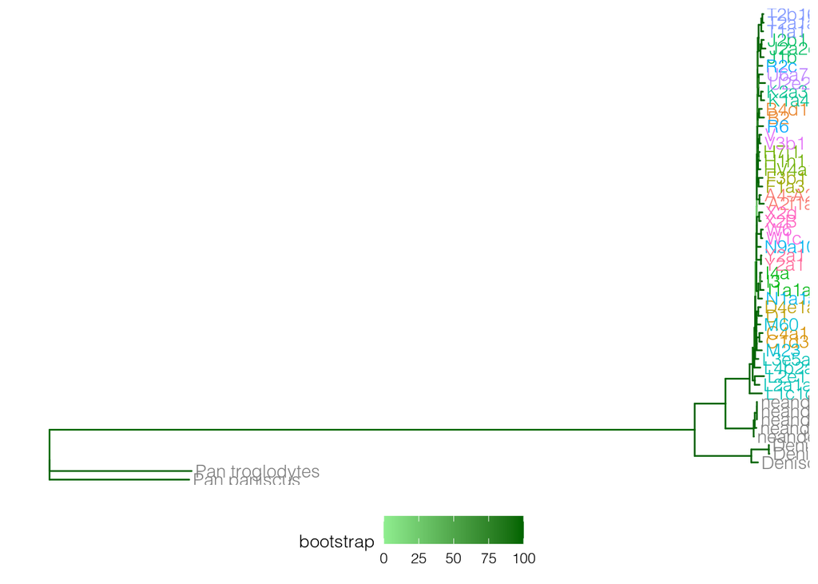

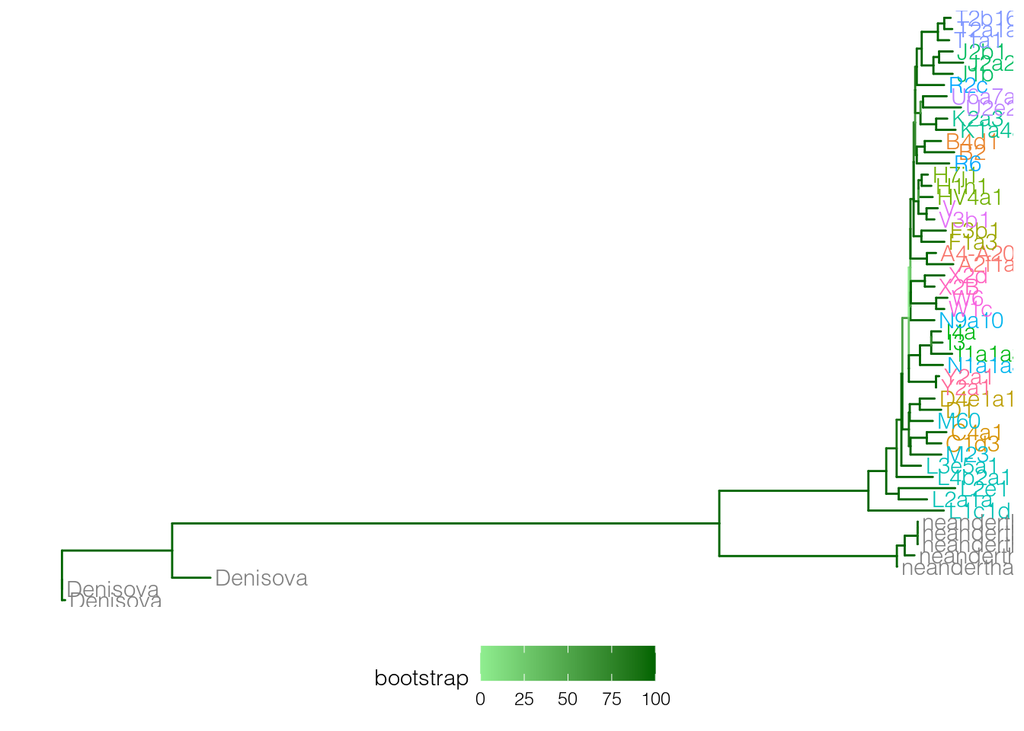

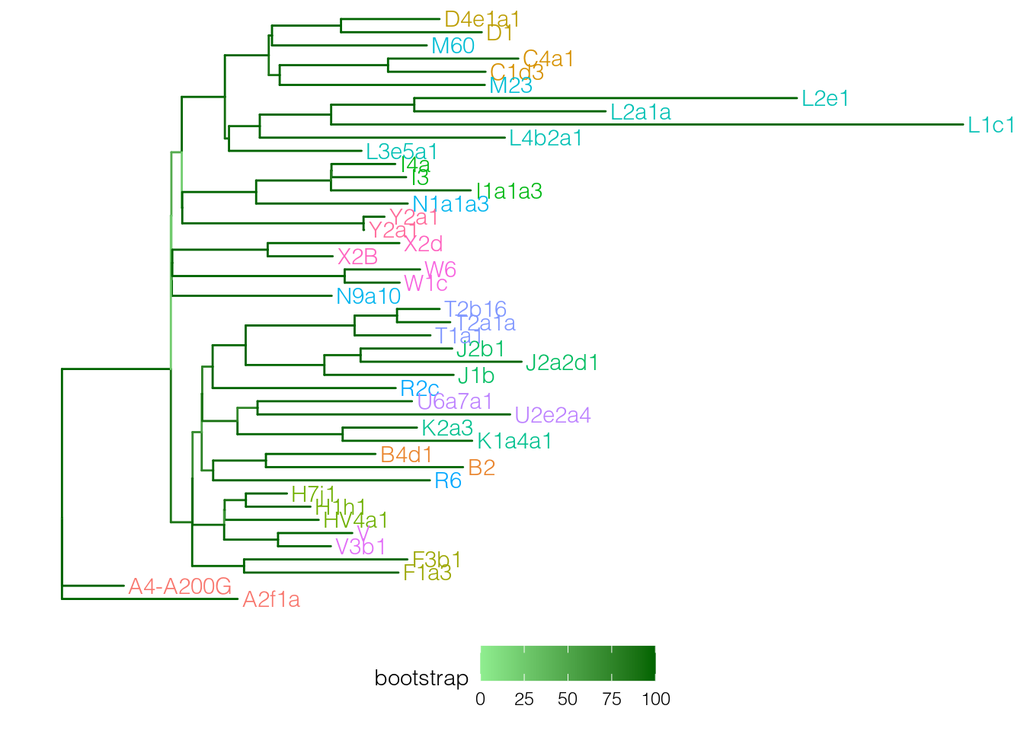

### Tree comparison

Let’s compare tree topology

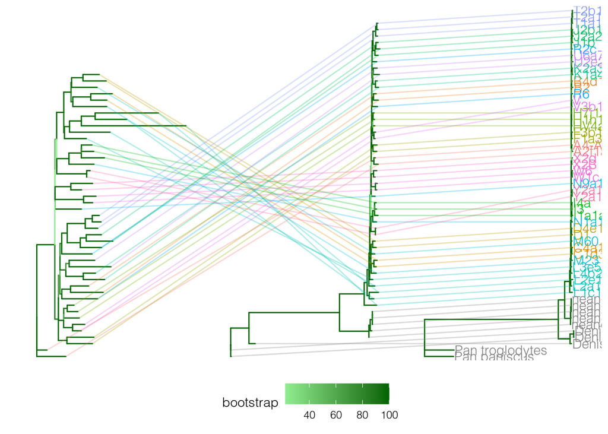

Phylogeny

A little differences between trees of homo and all humans, but only at *polytomy* point with low branch support

### Molecular clocks

To add molecular clock to data, I try to perform two adjustments:

- evaluating mutation rate + use mithochondrial molecular clock
- add paleonthological data (for trees 2 and 3)

#### Mutation rate

Read data

Get most distant sequences:

```r
mt <- human %>%
  as.phylo %>%
  cophenetic.phylo %>%
  as.matrix

top <- mt %>% unlist %>% sort(decreasing = T)
cat("Jackknife for top 25: ", top[50] %>% round(5))
```

```
## Jackknife for top 25:  0.00567
```

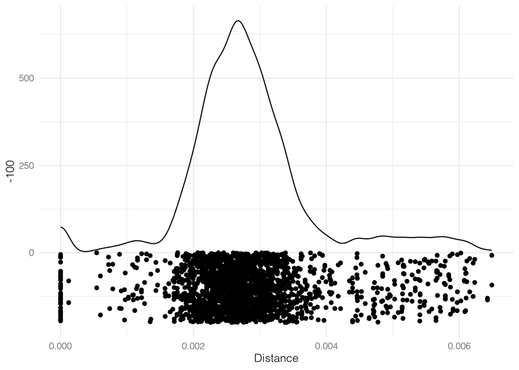

```r
ggplot(data.frame(x = top), mapping = aes(x)) +
  geom_density() +
  geom_jitter(aes(y = -100), height = 100, width = 0) +
  theme_minimal() +
  xlab("Distance")
```

```r
res <- tibble()
for (i in 1:nrow(mt)) for(j in i:ncol(mt)){
  if (mt[i,j] >= top[50]) {
    tmp <- data.frame(s1 = rownames(mt)[i],
                      s2 = colnames(mt)[j])
    res <- rbind(res, tmp)
  }
}

print(res)
```

```
##            s1         s2
## 1  JQ247408.1 FJ713601.1
## 2  KP172434.1 FJ713601.1
## 3  KY686210.1 FJ713601.1
## 4  HQ914447.1 FJ713601.1
## 5  KX440262.1 FJ713601.1
## 6  KX440275.1 FJ713601.1
## 7  JF837819.1 FJ713601.1
## 8  KX440315.1 FJ713601.1
## 9  JN419195.1 FJ713601.1
## 10 KY303770.1 FJ713601.1
## 11 KT698008.1 FJ713601.1
## 12 HQ189135.1 FJ713601.1
## 13 KT698006.1 FJ713601.1
## 14 HM804485.1 FJ713601.1
## 15 HQ259121.1 FJ713601.1
## 16 KU521454.1 FJ713601.1
## 17 KP017255.1 FJ713601.1
## 18 JF811749.1 FJ713601.1
## 19 FJ713601.1 KR135861.1
## 20 FJ713601.1 KY348642.1
## 21 FJ713601.1 GU590993.1
## 22 FJ713601.1 KM986616.1
## 23 FJ713601.1 KU508374.1
## 24 FJ713601.1 KY934478.1
## 25 FJ713601.1 HM448049.1
```

Calculate mutation rate:

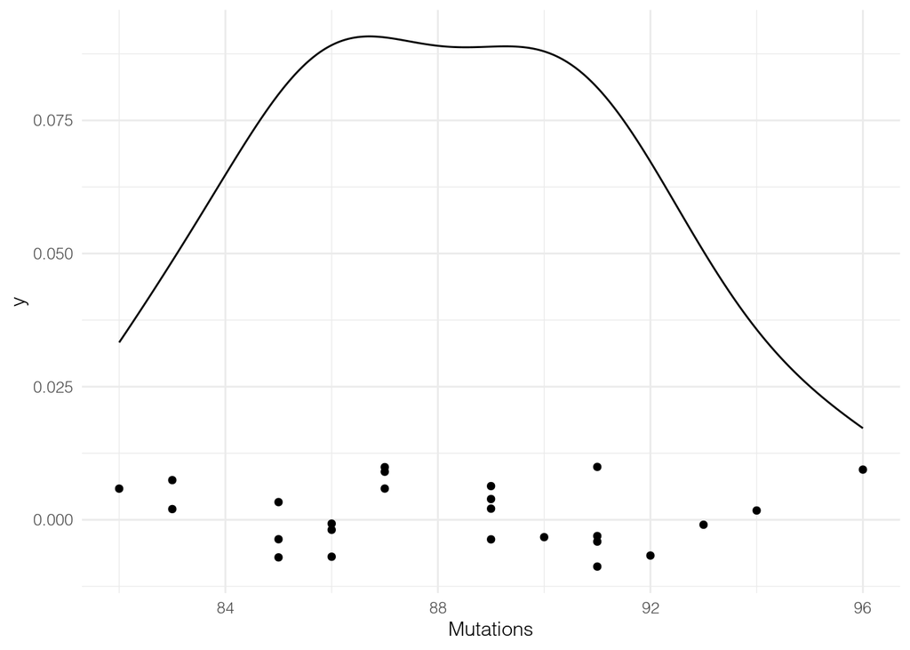

```r
mr <- c()
for (i in 1:nrow(res)) {
  s1 <- fa[[res[i,1]]]
  s2 <- fa[[res[i,2]]]

  mismatch = 0
  for (j in 1:length(s1)){
    if((s1[j] != s2[j]) &
       # only SNP
       !(s1[j] %in% c("N", "n", "-")) &
       !(s2[j] %in% c("N", "n", "-"))) {
      mismatch = mismatch + 1
    }
  }

  mr <- c(mr, mismatch)
}

ggplot(data.frame(x = mr), mapping = aes(x)) +
  geom_density() +
  geom_jitter(aes(y = 0), height = .01, width = 0) +
  theme_minimal() +
  xlab("Mutations")
```

I possibly can apply some big math and calculate the number of mutation differences in mtDNA that at least two people have using mathematical expectation on normal distributed value, but it should not work in this case, and some skylines should be better for this problem, so let’s use it as it is

Mutation rate was obtained from english wiki (i trust it):

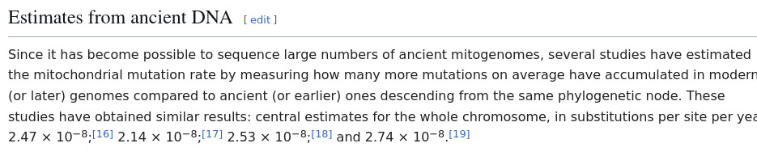

Estimate:

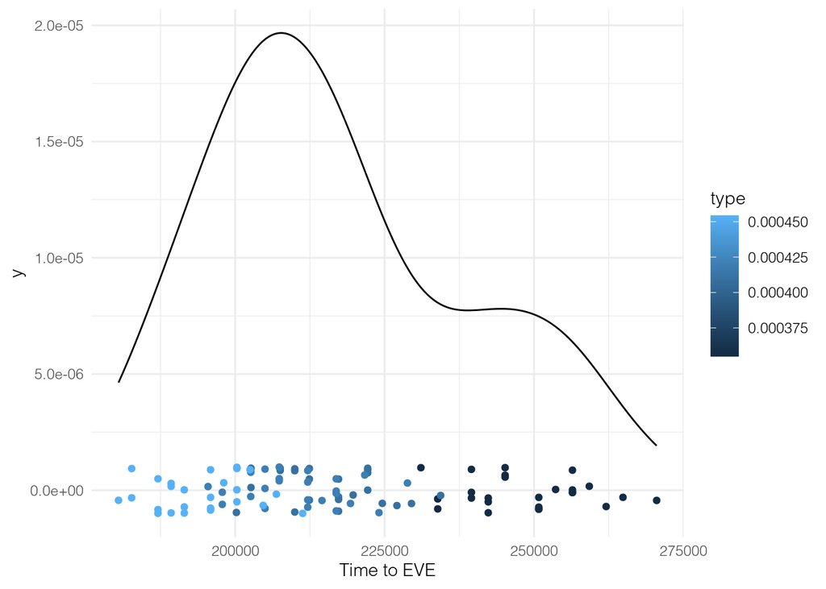

```r
MRs = c(2.14, 2.47, 2.53, 2.74) * 10^(-8) * length(fa[[1]])

data <- tibble()
for (i in MRs) {
  data <- rbind(data,
                data.frame(MR = mr/i, type = i))
}

ggplot(data, mapping = aes(MR)) +
  geom_density() +
  geom_jitter(aes(y = 0, color = type), height = 10^(-6), width = 0) +
  theme_minimal() +
  xlab("Time to EVE")
```

So, using this method actual estimated time is 180-270 thousands of years to LCA (mt EVE). Calibrating it to the distance, we have:

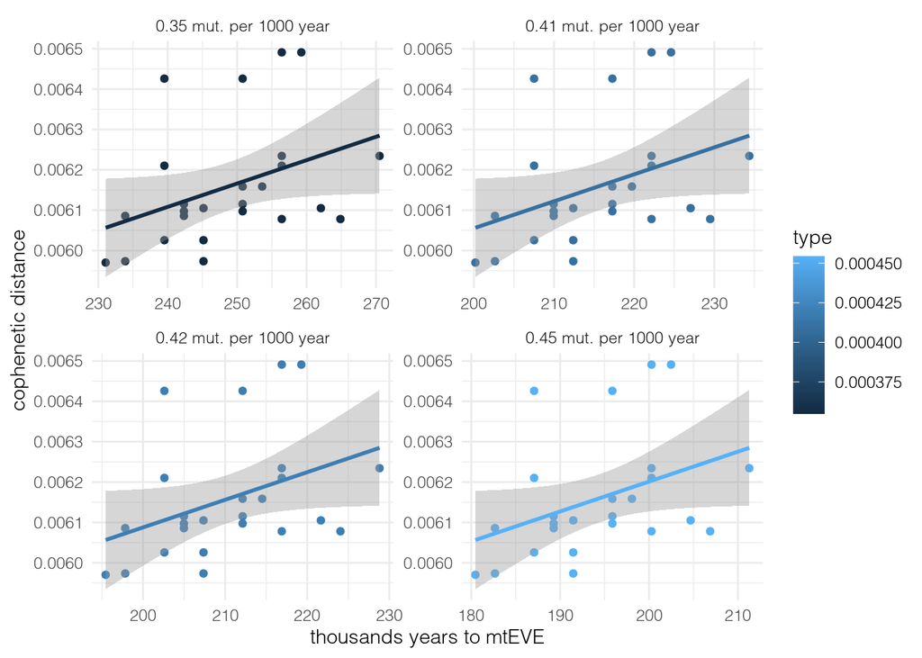

```r
data <- data %>%
  mutate(dist = rep(top[1:25],4)) %>%
  mutate(tp = type * 1000) %>%
  mutate(tp = paste0(round(tp,2), " mut. per 1000 year"))

ggplot(data, aes(MR/1000, dist, color = type, group = type)) +
  geom_point() +
  geom_smooth(method = "lm", formula = 'y~x') +
  facet_wrap(~tp, scales = "free") +
  xlab("thousands years to mtEVE") + ylab("cophenetic distance")+
  theme_minimal()
```

So average clock is ~ 34146.34 thousands of years per 1 value of cophenetic distance (*for humans*). Let’s calibrate using this info other trees:

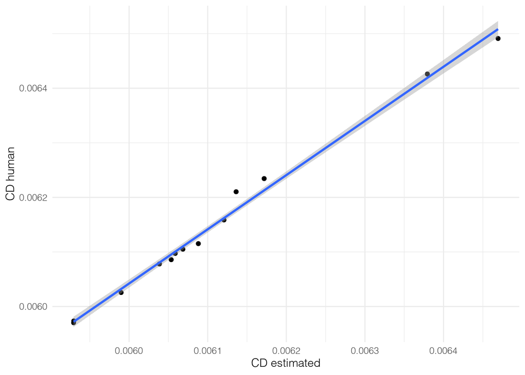

```r
human_calibr = 210/0.00615

human_coph <- function(ph) {
  lbs <- human$label[human$isTip]
   tmp <- ph %>%
      as.phylo %>%
      cophenetic.phylo %>%
      as.data.frame() %>%
      #subset by human labels
      subset(rownames(.) %in% lbs) %>% t %>%
      subset(rownames(.) %in% lbs) %>%
      unlist %>%
      sort(decreasing = T)


   gg <- data.frame(t1 = tmp[1:25],
              t2 = top[1:25]) %>%
    ggplot(aes(t1, t2)) +
    geom_point() +
    geom_smooth(method = "lm", formula = 'y~x') +
    xlab("CD estimated") + ylab("CD human")+
    theme_minimal()

   print(gg)

   CD = mean(tmp[1:25]/top[1:25])
   MR = human_calibr / CD

   return(MR)
}

full_calibr <- human_coph(full)
```

```r
homo_calibr <- human_coph(homo)
```

[figure not shown]

Rates are pretty similar

#### Paleo data

That is estimated that CHLCA have lived ~ 6 mln years ago. So we can compare mtEVE rate on the full tree with this estimation:

```r
CHLCA_dist <- full %>%
  as.phylo %>%
  cophenetic %>%
  max

CHLCA_calibr <- 6000/CHLCA_dist

cat(
  " mtEVE calibr:", full_calibr, "1000 years / distance value\n",
  "Paleo calibr:", CHLCA_calibr, "1000 years / distance value"
)
```

```
##  mtEVE calibr: 34377.43 1000 years / distance value
##  Paleo calibr: 30244.84 1000 years / distance value
```

Not that bad! Difference < 15% between estimations and paleonthology, which is obviously very good for this scenario. So we can finally add molecular clocks to the trees:

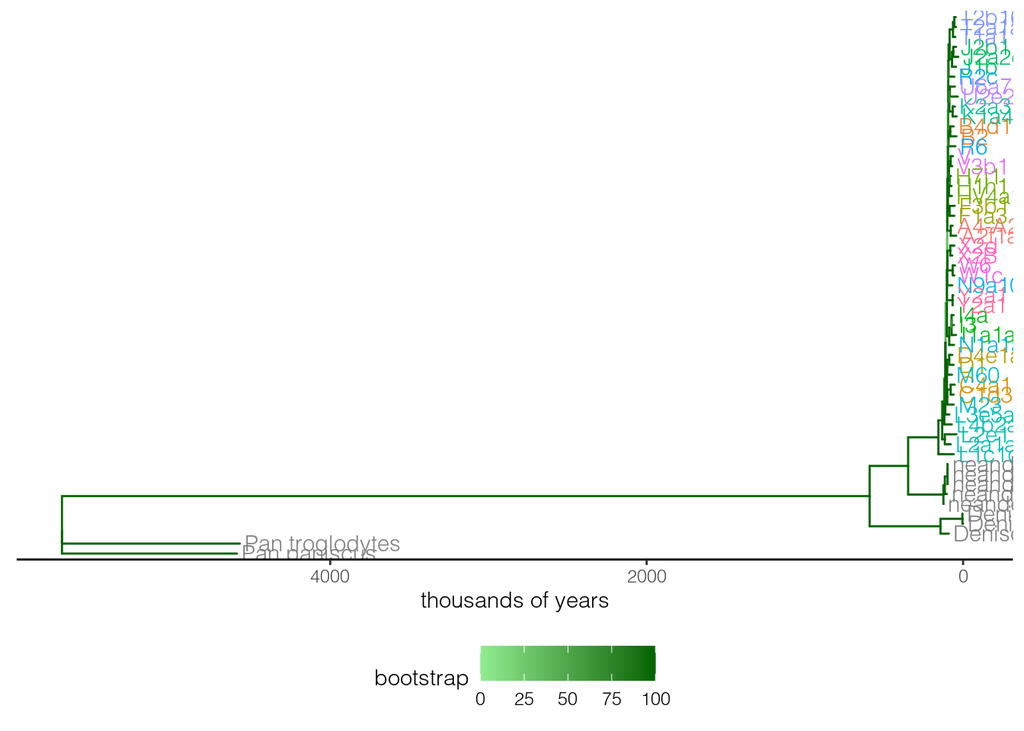

Phylogeny

```r
ggt <- function(inp, calibr){

  inp$label[inp$label == ""] <- 0
  inp$branch.length <- inp$branch.length * calibr
  inp$x <- inp$x * calibr

  gg <- ggtree(inp,
         aes(color = as.numeric(label))
         #, layout="circular"
         ) +
    scale_color_gradient(name = "bootstrap", low = "lightgreen", high = "darkgreen", na.value = "darkgreen") +
    ggnewscale::new_scale_color() +
    geom_tiplab(aes(color = color, label = clear), show.legend = F) +
    theme_tree2()  +
    theme(legend.position = "bottom") +
    xlab("thousands of years")

  revts(gg) +
    scale_x_continuous(labels = abs)

}

ggt(full, full_calibr)
```

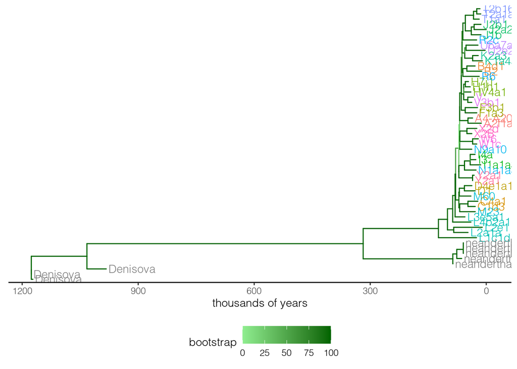

Phylogeny

```r
ggt(homo, homo_calibr)
```

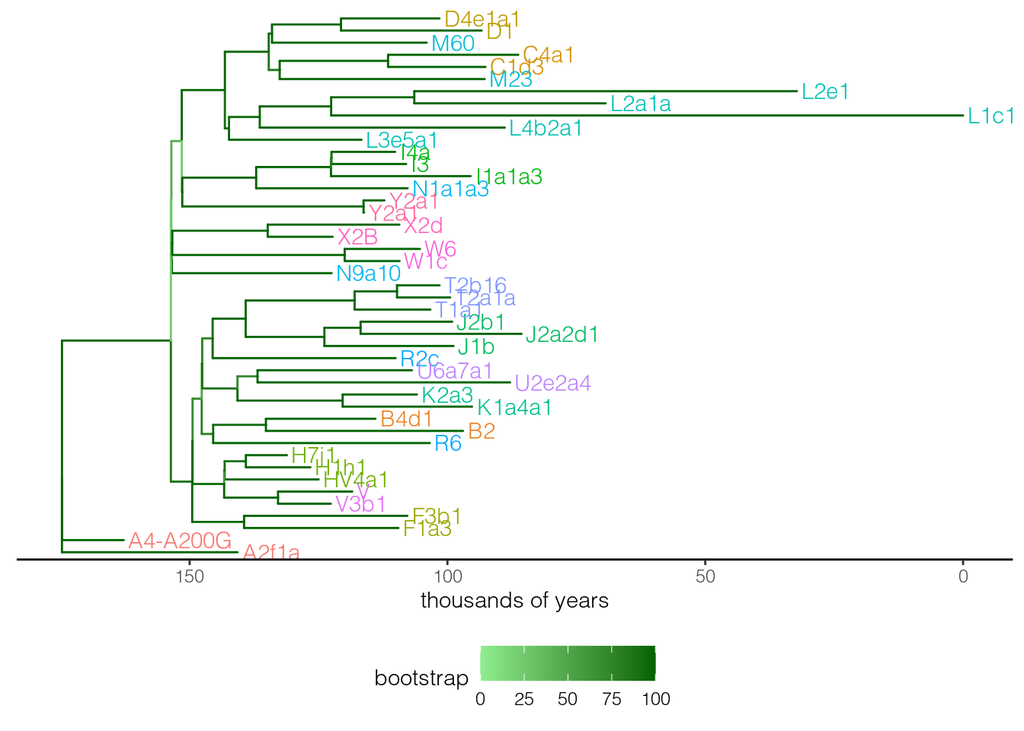

Phylogeny

```r
ggt(human, human_calibr)
```

Pretty good results, with good connection to known data!